# Chapter 5

5/20/2015

## Overview

In this chapter, we will discuss:

- Standardizing Values with Z-Scores
- Shifting and Scaling Distributions
- Normal Models
- Finding Normal Percentiles
- Assessing Normality

## Review

From Chapter 3:

- A *symmetric distribution* is one that is "mirrored" around the center
- A *unimodal distribution* has one peak
- In a symmetric distribution, the *mean* and the *median* are the same
- If the data is *skewed*, we can often *re-express* it so that it is symmetric

In this chapter, we will concentrate on unimodal, symmetric distributions

- The sample mean is the measure of center, it is the "balancing point" of the distribution.
- The sample standard deviation is the measure of spread, it tells us how far, on average, observations are from the mean

## Review (cont.)

We calculate the mean as:

- \(\bar{x} = \frac{\sum x}{n}\)

And the Standard Deviation as:

- \(s = \sqrt{\frac{\sum (x - \bar{x})^2}{n - 1}}\)

Recall:

- \(n\) is our *sample size* or number of observations

Generally, we will use software like StatCrunch to find these values for us

## The Data

For this chapter, we will compare the SAT and ACT scores of 10000 students who took both exams.

```
##       ID      SAT      ACT
## 1 338861 1417.255 28.87883
## 2 801180 1275.967 21.93852
## 3 252174 1509.345 20.92183
## 4 858407 1413.393 24.02147
## 5 819949 1606.584 24.25653
## 6 970656 1593.724 19.32590
```

## Visualizing SAT Scores

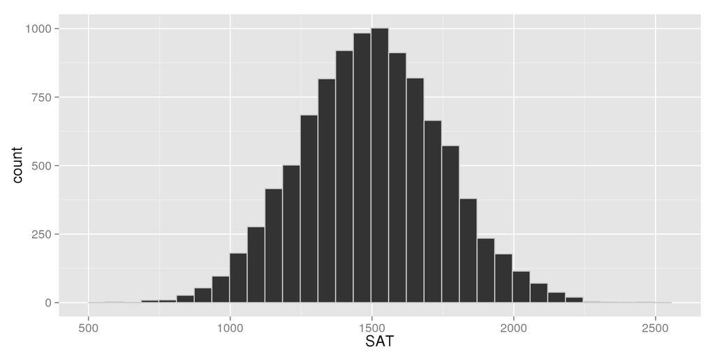

## Visualizing ACT Scores

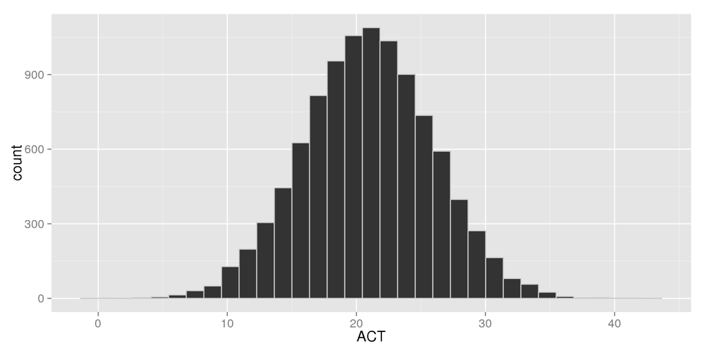

## Comparing Distributions

Both variables are unimodal and symmetric, but looking at the values we see that they both have very different scales.

We may want to compare the distributions. Recall that we have two main ways of doing this for numeric variables:

- Side-by-Side Histograms
- Side-by-Side Boxplots

Because the variables have very different scales, comparing them may be difficult

## Side-by-Side Histograms

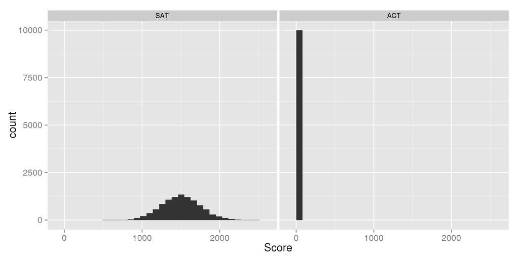

## Side-by-Side Boxplots

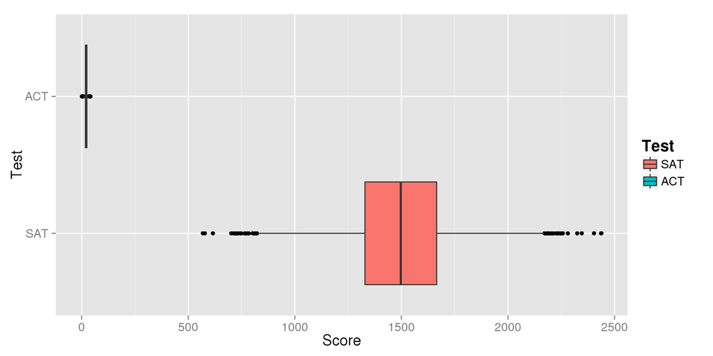

## Numerical Summaries

Obviously, we can tell from the plots that the distributions are very different. Let's look at our quantitative measures to see just how different:

```
##         Min. 1st Qu. Median 3rd Qu.   Max.
## SAT 568.2000 1329.00 1497.0 1666.00 2439.0
## ACT   0.4642   17.56   20.9   24.32   41.4
```

Because the distributions are symmetric, we can also look at the sample means and standard deviations:

```
##     Mean     St.Dev
## SAT 1498.168 248.9613
## ACT 20.92007 5.008556
```

For simplicity's sake, let's call the means 1500 and 21 and the standard deviations 250 and 5, respectively.

## Standardizing with Z-Scores

What we've seen here is the problems that occur when we compare distributions with different scales. We typically deal with this by *standardizing* our variables with *z-scores*.

For a given distribution, we define as z-score as:

- \(z = \frac{x - \bar{x}}{s}\)

For our each of our students, we can find the standardized SAT and ACT scores as:

- \(z_{SAT} = \frac{SAT - \overline{SAT}}{s_{SAT}} = \frac{SAT - 1500}{250}\)
- \(z_{ACT} = \frac{ACT - \overline{ACT}}{s_{ACT}} = \frac{ACT - 21}{5}\)

## Side-by-Side Histograms of the Z-Scores

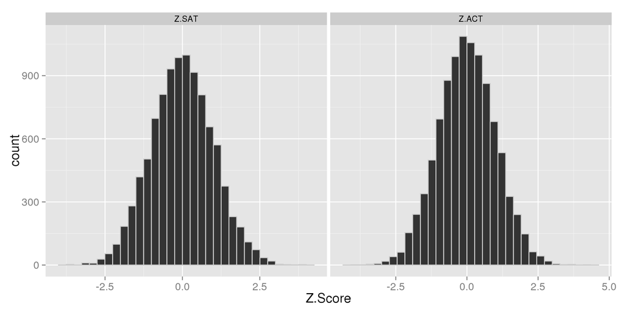

## Side-by-Side Boxplots

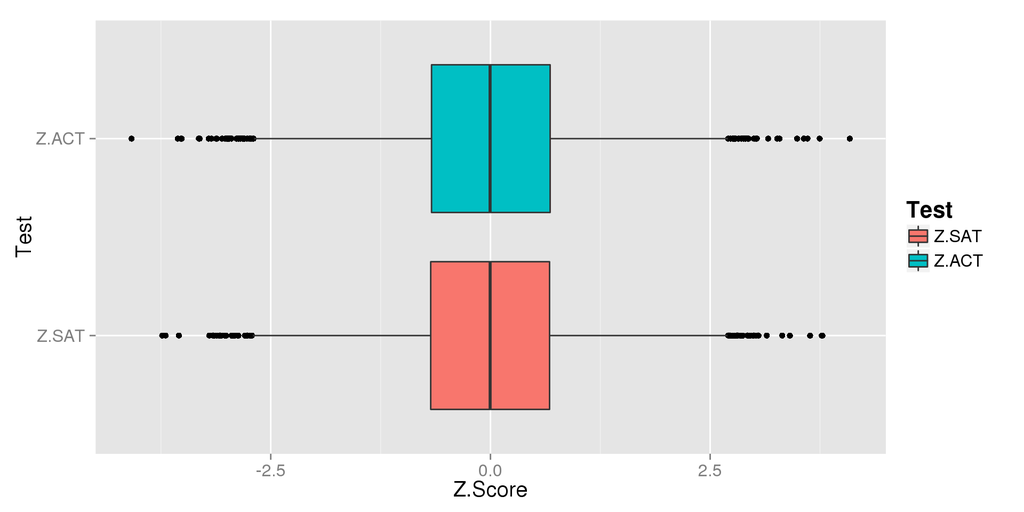

## What did Standardizing Do?

To see exactly what happened, let's look at our numerical summaries.

Five Number Summaries:

```
##         Min. 1st Qu.    Median 3rd Qu.  Max.
## Z.SAT -3.735 -0.6798 -0.003724  0.6724 3.778
## Z.ACT -4.084 -0.6704 -0.004263  0.6791 4.088
```

Means and Standard Deviations:

```
##       Mean St.Dev
## Z.SAT 0    1
## Z.ACT 0    1
```

## Why Standardizing?

For any symmetric distribution, standardizing by finding the z-scores:

- Forces the mean to 0 and the standard deviation to 1

This allows us:

- To compare two (or more) distributions on the same scale
- Directly compare observations from each distribution in terms of their z-scores

Z-Scores have other uses that we'll discuss later

## What is a Z-Score?

\[ z = \frac{x - \bar{x}}{s}\]

Breaking it down:

- \(x - \bar{x}\) is how far a point is from the mean
- Divinding by \(s\) tells us how many standard deviations fit into the difference

Putting it together:

- For any observation, its z-score is its *distance from the mean, measured in standard deviations*
- If a z-score is **positive**, that observation is **higher** than the mean
- If a z-score is **negative**, that observation is **below** the mean

## Using Z-Scores to Compare Observations

Let's look at one particular student who scored 1725 on the SATs and 27 on the ACTs.

Which score should she send with her application?

Compared to her peers:

- This student's SAT score was 0.9 standard deviations higher than average
- This student's ACT score was 1.2 standard deviations higher than average
- She did better on the ACTs than the SATs

## Using Z-Scores to Compare Observations

Let's look at another student who scored 1475 on the SATs and 20 on the ACTs.

Which score should she send with her application?

- \(Z_{SAT} = \frac{SAT - \overline{SAT}}{s_{SAT}} = \frac{1475 - 1500}{250} = -\frac{25}{250} = -0.1\)
- \(Z_{ACT} = \frac{ACT - \overline{ACT}}{s_{ACT}} = \frac{20 - 21}{5} = -\frac{1}{5} = -0.2\)

Compared to her peers:

- This student's SAT score was 0.1 standard deviations lower than average
- This student's ACT score was 0.2 standard deviations lower than average
- She did better on the SATs than the ACTs

## Why Z-Scores Work: Shifting and Scale

We call what z-scores do *centering and scaling*.

- We *shift* the mean so the scores are centered around zero
- We *scale* the variable so its standard deviation is one

In general:

- If we add (or subtract) a constant to *every* value, all measures of position (the mean and five number summary) are shifted by that constant
- If we multiply (or divide) by a constant, the standard deviation is scaled by that constant
- a constant is just a number that doesn't change

## Shifting Example

Consider the data set: \(1,\; 3,\; 5,\; 7,\; 9\)

- \(\bar{x} = \frac{\sum x}{n} = \frac{1 + 3 + 5 + 7 + 9}{5} = \frac{25}{5} = 5\)

Now let's add 3 to every number: \(4,\; 6,\; 8,\; 10,\; 12\)

- \(\bar{x} = \frac{4 + 6 + 8 + 10 + 12}{5} = \frac{40}{5} = 8\)

What happened?

- By adding 3 to every number, we *shifted* the mean by 3
- Every number in the five number summary also goes up by 3

## Shifting in Practice

- The mean of the exam scores is now \(1500 - 1750 = -250\) instead of \(1500\), which means the average student does not meet their requirements

What will happen to the histogram?

## Histogram of SAT Scores

The red line represents the cut-off:

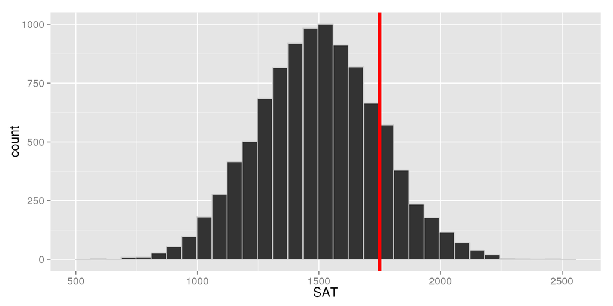

## Histogram of Shifted SAT Scores

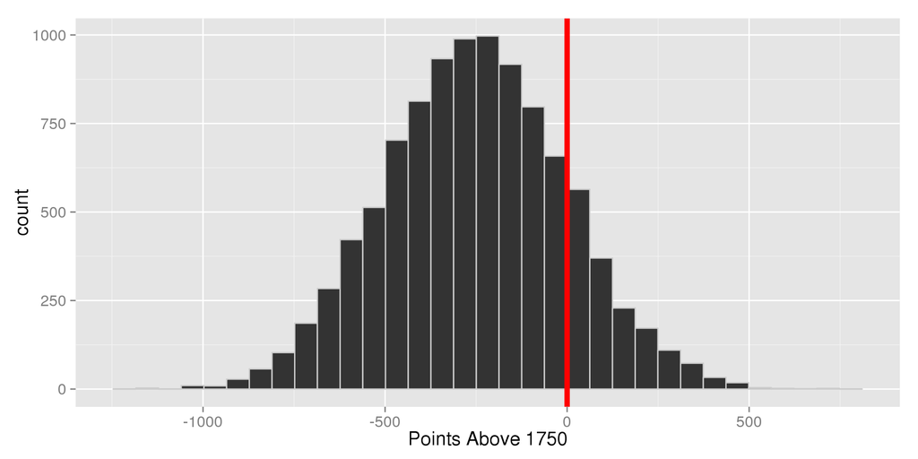

## Shifting: Summaries

Let's see what happened to our summary stats:

```
##             Min     Q1 Median     Q3    Max    IQR   Mean  SD
## SAT       568.2 1328.9 1497.2 1665.6 2438.6 -336.7 1498.2 249
## Shifted -1181.8 -421.1 -252.8  -84.4  688.6 -336.7 -251.8 249
```

Notice:

- All measures of *position* (the five number summary and mean) were shifted down by 1750
- Both measures of *spread* (the SD and IQR) stayed the same

Say we're interested in the weights of the cars from the Motor Trend data set we used in the previous chapter, but we're writing for a European magazine which expects the weights in kilograms.

- The standard deviation of weight was 978.5 lbs.

What's the standard deviation in kg?

- \(1 lb = 0.454kg\)
- \(s = 978.5 lbs = (978 \times 0.454) kg = 444.2 kg\)

How do the distributions compare if we change the units?

## Visualizing Scaling

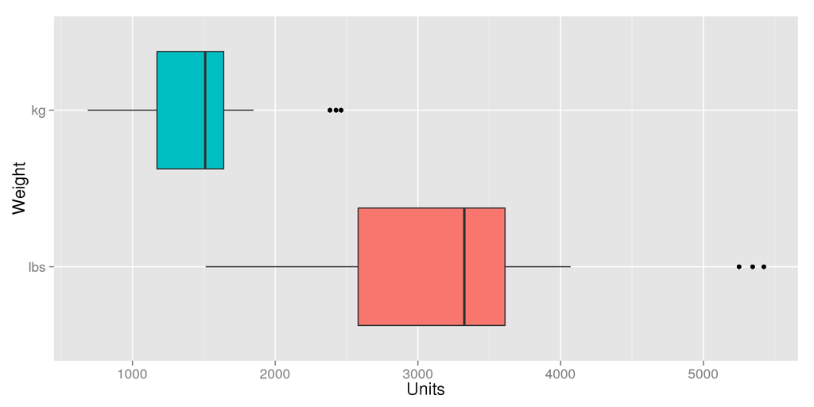

## Scaling: Summaries

Let's see what happened to the numerical summaries:

```
##                 Min     Q1 Median     Q3    Max     IQR   Mean    SD
## Weight (lbs) 1513.0 2542.5 3325.0 3650.0 5424.0 -1107.5 3217.2 978.5
## Weight (kg)   686.9 1154.3 1509.5 1657.1 2462.5  -502.8 1460.6 444.2
```

Notice:

- *All* measures of position and scale we scaled down
- The oppostite would be true had we multiplied by a number larger than one

## The Normal Model

So far, we've talked generically about symmetric, unimodal distributions. The *Normal Model* or *Normal Distribution* is a special type of symmetric unimodal distribution.

- The shape of Normal Model is defined entirely by it's mean and standard deviation
- The Normal Distribution show up naturally almost any time we take measurements (height, weight, length, etc.)
- Many exams and tests (IQ, SATs, GREs, etc.) are designed so that their scores follow a Normal Distribution
- Most of the statistical tests we'll talk about in the course assume that the variable(s) follow a Normal Distribution

## The Normal Curve

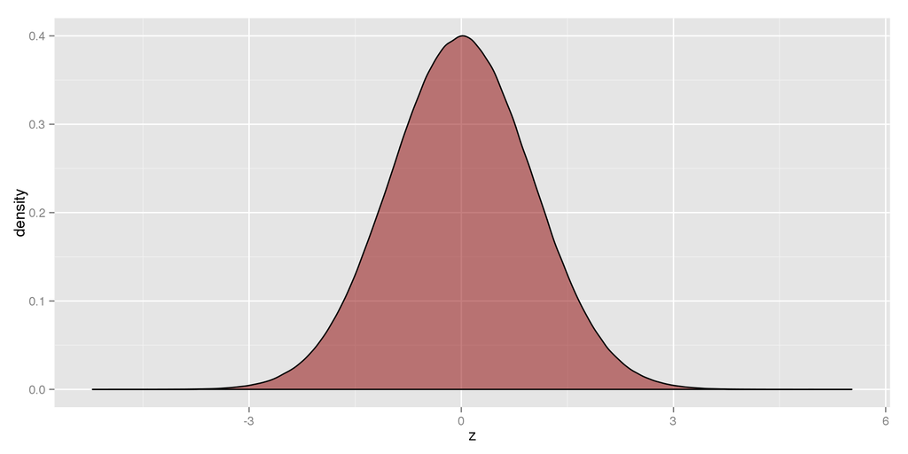

## The Shape of the Normal Model

The Normal Model is:

- Unimodal
- Symmetric about the Mean
- Bell-Shaped

Because the distribution is symmetric,

- The Mode = The Mean = The Median

## Describing a Normal Distribution

If a variable \(X\) has a normal distribution with mean \(\mu\) and standard deviation \(\sigma\), we write this as:

\[ X \sim N\left(\mu, \sigma\right) \]

This is read as:

- "X is distributed normally with mean mu (mew) and standard deviation sigma"

Quick remark about notation:

- Typically, when we refer to a variable, we use upper-case letters
- When we refer to the variable take a particular value, we use lower-case letters
- \(X = x\) means *a particular value of* \(X\), e.g. \(X = 3\)

## Why the Greek Letters?

- The means and standard deviations we've calculated so far only describe a *sample* or a group of observed values.
- A number that describes a sample is called a *statistic*, and they are usually represented with Roman letters (e.g., \(\bar{x}\), \(s\))
- Samples are drawn from larger *populations* which we are usually trying to describe or study.
- When we write the distribution, we are describing the entire population
- Numbers that describe the population are called *parameters*
- The sample statistics are usually to estimate the parameters, but they are usually off by a bit because we don't have the entire population to use in the calculation

## Z-Scores for Populations

Earlier, we defined a z-score as:

- \(z = \frac{x - \bar{x}}{s}\)

If don't know anything about the population, this is the best we can do.

If we do know the population parameters, however, we can write:

- \(z = \frac{x - \mu}{\sigma}\)

What's the difference?

- The first one talks about where a value falls *in the sample*
- The second one tells us where the data falls *in the population*
- If we know \(\mu\) and \(\sigma\), we should use them

## Standard Normal Distributions

The problem with normal distributions is that there is a unique distribution for every possible combination of \(\mu\) and \(\sigma\). This means that there are an infinite number of normal distributions.

It turns out there's a way to convert **any** normal distribution to one that has \(\mu = 0\) and \(\sigma = 1\), which we call the *Standard Normal Distribution*. This lets us compare different normal distributions to each other more easily.

If \(X \sim N(\mu, \sigma)\):

- For every value of \(X\), find \(z = \frac{x - \mu}{\sigma}\)
- \(Z \sim N(0, 1)\)

## Statistics vs. Parameters: SAT

Recall that we rounded liberally when we said \(\overline{SAT} = 1500\) and \(S_{SAT} = 250\), the real values were:

```
##         Mean   St.Dev
## SAT 1498.168 248.9613
```

I did primarily to make the z-score calculations easier, but it turns out the SAT is created in such a way that:

\[ SAT \sim N\left(\mu = 1500, \sigma = 250\right) \]

The larger our sample is, the closer to the true value of the parameters our statistics will be.

In practice, we usually don't know what \(\mu\) and \(\sigma\) are supposed to look like.

## The 68-95-99.7 Rule

In addition to being bell-shaped, symmetric, and unimodal, the Normal Distribution has another nice feature, called the *68-95-99.7 Rule*:

- About 68% of the data is within one standard deviation of the mean
- About 95% of the data is within two standard devations of the mean
- About 99.7% of the data is within three standard deviations of the mean

This holds for any variable that follows The Normal Model, no matter what \(\mu\) and \(\sigma\) are.

Important Notes:

- The percentages are **approximate**, but they can give us a good idea of what to expect
- Almost all individuals fall within three standard deviations of the mean

## Visualizing the 68-95-99.7 Rule

[figure not shown]

## 68-95-99.7 Rule in Practice (1)

As we've said, SAT scores are designed to follow a Normal Distribution: \[SAT \sim N\left(\mu = 1500, \sigma = 250\right)\]

## 68-95-99.7 Rule in Practice (2)

\[SAT \sim N\left(\mu = 1500, \sigma = 250\right)\]

What was the cut-off for the lowest 2.5% of people?

- 95% score within two standard deviation
- This means 5% are more than two standard deviations away from the mean on either side
- The Normal Distribution is symmetric about the mean, so only 2.5% scored more than two standard deviations below the mean
- Two standard deviations below the mean is: \(\mu - 2\sigma = 1500 - 2(250) = 1500 - 500 = 1000\)
- 2.5% of people scored less than 1000 on the SATs

## 68-95-99.7 Rule in Practice (3)

\[SAT \sim N\left(\mu = 1500, \sigma = 250\right)\]

What percent of people scored higher than 2250?

- We need to know how many standard deviations above the mean 2250 is, which is the z-score for 2250
- \(z = \frac{x - \mu}{\sigma} = \frac{2250 - 1500}{250} = \frac{750}{250} = 3\)
- 2250 is three standard deviations above the mean
- 99.7% of people score within three standard deviations of the mean, so \(100\% - 99.7\% = 0.3\%\) scored more than three away from the mean
- Because Normal Distributions are symmetric, this is split evenly above and below the mean
- Only \(0.3\% / 2 = 0.15\%\) of people scored higher than 2250

## Finding Percentiles of Normal Distributions

A *percentile* is the value that cuts of some percentage of the distribution.

- For example, 25% of values are below \(Q1\), so \(Q1\) is the 25th Percentile
- As we saw, the 68-95-99.7 rule can give us percentiles (1000 was the 2.5th Percentile, 2250 was the 99.85th Percentile)
- The 68-95-99.7 only gives us *approximate* percentages or percentiles
- The 68-95-99.7 only lets us look at values that are exactly 1, 2, or 3 standard deviations away from the mean.

What's the alternative?

- We can use the shape of the Normal Model to find exact percentiles
- In this class, we use StatCrunch to do this

## Writing Percentiles

StatCrunch and other calculators look for percentiles in specific formats. In either case, we start by telling StatCrunch \(\mu\) and \(\sigma\).

How would I ask for the 95th Percentile?

- \(P(X \le x) = 0.95\)
- Note that we wrote the *percentage* as a *proportion*
- StatCrunch will fill in the value for \(x\)

If we wanted to know what percent of people scored higher than 2100:

- \(P(X \ge 2100) = p\)
- StatCrunch will solve for the proportion, which we need to turn into a percentage

## StatCrunch: 95th Percentile

[figure not shown]

## StatCrunch: 95th Percentile

[figure not shown]

## StatCrunch: \(P(X \ge 2100)\)

[figure not shown]

## StatCrunch: \(P(X \ge 2100)\)

[figure not shown]

## Percentages of Ranges

\[SAT \sim N\left(\mu = 1500, \sigma = 250\right)\]

What percentage scored between 1480 and 1530?

- We write this as \(P(1480 \le X \le 1530) = p\)
- StatCrunch will find \(p\) for us if we select `Between` at the top of the Normal Calculator
- \(P(1480 \le X \le 1530) = 0.0796 = 7.96\%\)

## StatCrunch: \(P(1480 \le X \le 1530)\)

[figure not shown]

## StatCrunch: \(P(1480 \le X \le 1530)\)

[figure not shown]

## Cut-offs for Percentages

\[SAT \sim N\left(\mu = 1500, \sigma = 250\right)\]

Say we wanted to find the IQR of the population of SAT scores. To do this, we need to find \(Q1\) and \(Q3\). Unfortunately, StatCrunch cannot compute this directly.

We need to break it down:

- \(P(Q1 \le X \le Q3) = 0.5\)
- \(P(X \le Q1) = 0.25\)
- \(P(X \ge Q3) = 0.25\)
- Let StatCrunch find \(Q1\) and \(Q3\), then \(IQR = Q3 - Q1\)

## StatCrunch: Population Q1

[figure not shown]

## StatCrunch: Population Q3

[figure not shown]

## Finding Population IQR from StatCruch

From StatCrunch, we found:

- \(P(X \le Q1) = 0.25 \to Q1 = 1331.4\)
- \(P(X \ge Q3) = 0.25 \to Q3 = 1668.6\)
- \(IQR = Q3 - Q1 = 1668.6 - 1331.4 = 337.2\)

We can use the same process for any middle percentage. Say we want the middle 80%:

- \(P(lower \le X \le upper) = 0.8\)
- \(P(X \le lower) = 0.1\)
- \(P(X \ge upper) = 0.1\)
- Use StatCrunch to find the lower and upper cut-offs

## Assessing Normality

The techniques we've been discussing only work if the data follow the Normal Model.

Before blindly assuming that a variable has a Normal Distribution, we should first check whether or not it does. We have two ways to do this:

- Make a histogram: is it unimodal, symmetric, and bell-shaped?
- Make a QQ Plot: do the points make a straight line?

Notes:

- For small sample sizes, histograms can be unreliable (as we've seen)
- It doesn't have to be perfect, we're looking for "close enough"

## QQ Plots

QQ is short for Quantile-Quantile

- A quantile is just a value that cuts the distribution at a certain place (quartiles are a specific type of quantile that cuts the data into 4\(^{th}\)s).
- QQ Plots, compare the quantiles we would see if the distribution *were Normal* to the quantiles that we actually have in our data.
- If our data is Normal, we'll be able to draw a (mostly) straight line through the points.

Making a QQ Plot:

- Each observation is plotted as a point
- The x and y coordinates are given by the theoretical (Normal) quantiles and the observed quantiles, respectively
- In StatCrunch: `Graph` \(\to\) `QQ Plot`

## QQ Plot Example: Normal Data

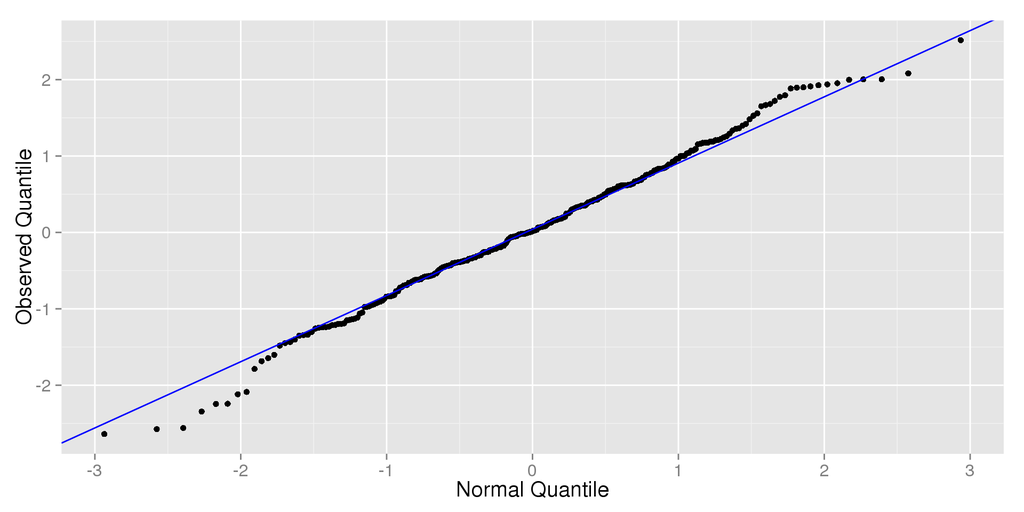

## QQ Plot Example: Non-Normal Data

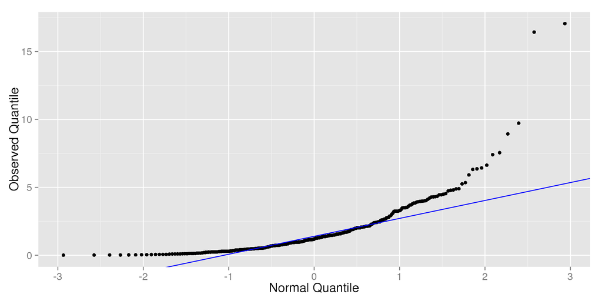

## Assessing Normality

To show you how these work, I generated two samples that I know come from a \(N(\mu = 100, \sigma = 10)\) distribution.

- Sample 1 has twenty observations \((n = 20)\)
- Sample 2 has a sample size of two hundred \((n = 200)\)

## Sample 1: Histogram

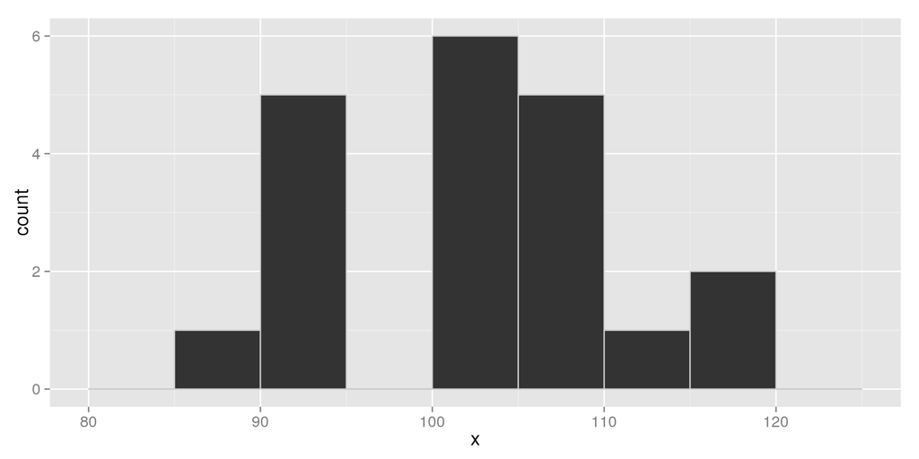

## Sample 2: Histogram

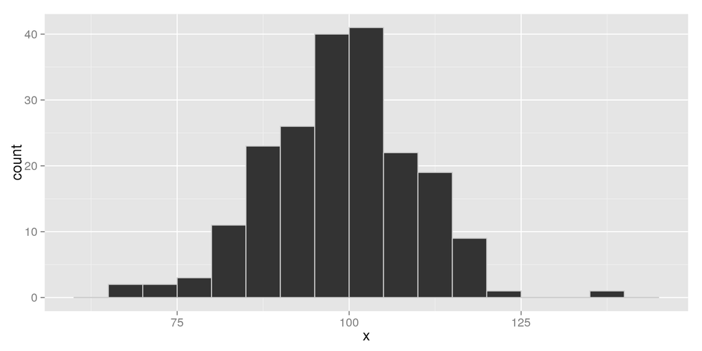

## Sample 1: QQ Plot

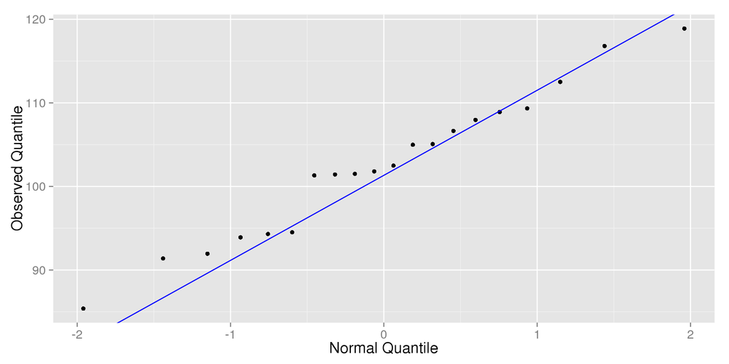

## Sample 2: QQ Plot

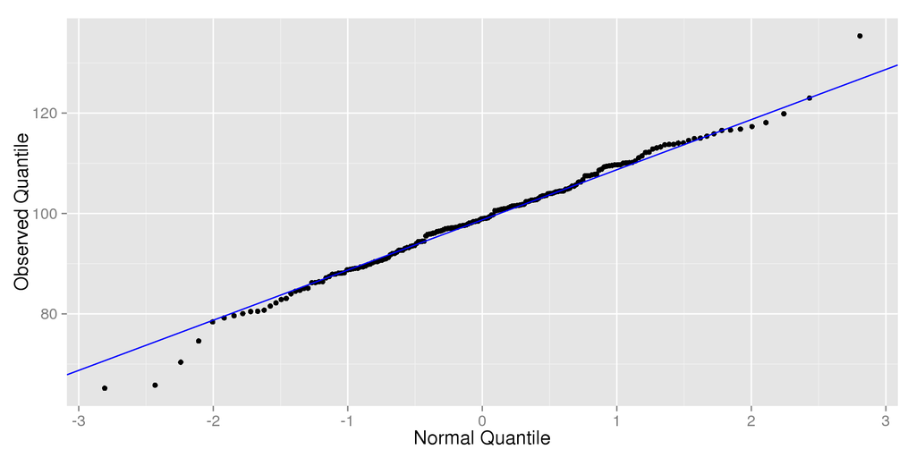

## Summary

- We can compare two distributions by standardizing them with z-scores
- We can compare observations from different distributions using z-scores
- Adding or (subtracting) a constant to every value moves the distribution up or down
- Multiplying or dividing every value by a constant stretches or shrinks a distribution
- Normal Distributions are widely used distributions with convenient properties
- We can find the percentage of values in a range from a Normal Distribution using the 68-95-99.7 rule or software
- We can assess Normality using Histograms or QQ Plots (but QQ plots are better)